# Advanced Statistical Inference I

Chelsea Parlett-Pelleriti

# Inference Review

## Bayes vs. Freq

- Bayesians think **parameters** ($\theta$) are random (think multiverse) and **data** are fixed
  - Bayesians make probability statements about parameters
  - Bayesians imagine what values parameters might take on in different universes
  - Bayesians use probability distributions (priors and posteriors) to describe the uncertainty they have about what a parameter value might be

## Bayes vs. Freq

- Frequentists think **data** are random (think repeated sampling) and **parameters** ($\theta$) are fixed
  - Frequentists make probability statements about sample statistics (mean, CI)
  - Frequntists imagine what our estimates might look like under repeated samples from the same population
  - Frequentists care about long run error rates (e.g. $\alpha$ which is our Type I error rate in a NHST test)

## Parameter Estimation vs. Hypothesis Testing

- **Parameter Estimation** asks “What is the value of this parameter?”
  - Honing in on a value
- **Hypothesis Testing** asks “Which hypothesis is supported?”
  - making a discrete decision (e.g. reject, fail to reject)

## Frequentist PE and HT

- Frequentist PE: Confidence Intervals, Standard Errors, and Test Statistics
- Frequentist HT (NHST): p-values, $\alpha$, statistical power

## Bayesian PE and HT

- Bayesian PE: Posterior Means/Medians, Credible Intervals (HDI, ETI), Posterior Summaries (e.g. $p(x > 0)$)
- Bayesian HT: Posterior Odds, Bayes Factors, Credible Interval Overlap

# Bayesian Regression Models

## Regression (GLM) Model Review

$$\mathbb{E}\left (y | \mathbf{X}\right ) = \mu = g^{-1}\left (\mathbf{X}\beta \right ) \\
p\left (y|x\right ) \sim \pi\left (\mu,...\right )$$

- link function: $g()$
- likelihood function: $\pi()$

## Linear Regression Review

$$y_i \sim \mathcal{N}(\mu_i, \sigma^2) \\
\mu_i = \mathbf{X_i}\beta = \beta_0 + \beta_1 \cdot x_{i1} + ... + \beta_n \cdot x_{in}$$

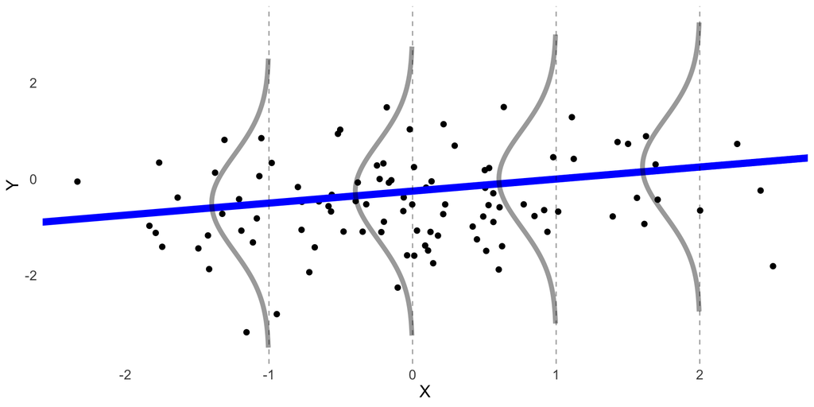

## Bayesian Linear Regression

$$y_i \sim \mathcal{N}(\mu_i, \color{red}\sigma^2) \\
\mu_i = \mathbf{X_i}\color{red}\beta = \color{red}\beta_0 + \color{red}\beta_1 \cdot x_{i1} + ... + \color{red}\beta_n \cdot x_{in}$$

[figure not shown]

# Setting Priors

## Choosing BLR Priors

Let’s look at a regression model that uses **age** to predict **income** (in thousands).

$$\underbrace{\mu_i}_{\mathbb{E}(\text{income})} = \color{red}{\beta_0}+ \color{red}{\beta_1} \cdot age_i \\
\text{income}_i \sim \mathcal{N}(\mu_i, \color{red}{\sigma^2})$$

$$\beta_0 \sim \mathcal{N}(m_0, s_0^2); \beta_1 \sim \mathcal{N}(m_1, s_1^2);\sigma \sim \Gamma(0.1,10)$$

❓ What other distributions might be reasonable for our two $\beta$s?

## Choosing BLR Priors

$\beta_0 \sim \mathcal{N}(0, 1); \beta_1 \sim \mathcal{N}(2, 4);\sigma \sim \Gamma(0.1,10)$

We put priors on (*at least*) all parameters in our model.

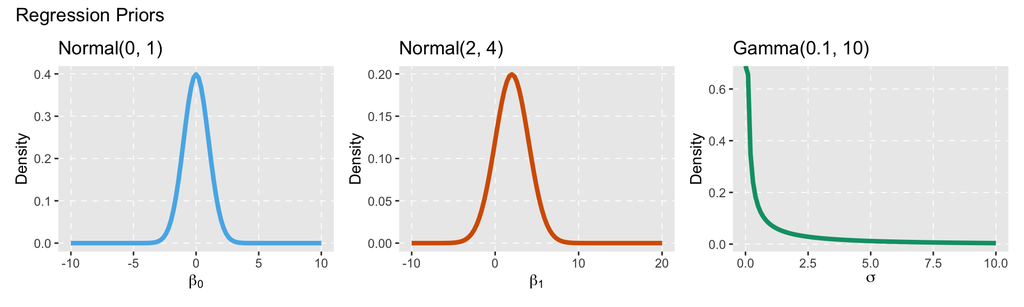

## Uniform Priors

If we do not set priors, most software will *assume* **default priors**. In some cases, this means **Uninformative** Uniform **Priors.**

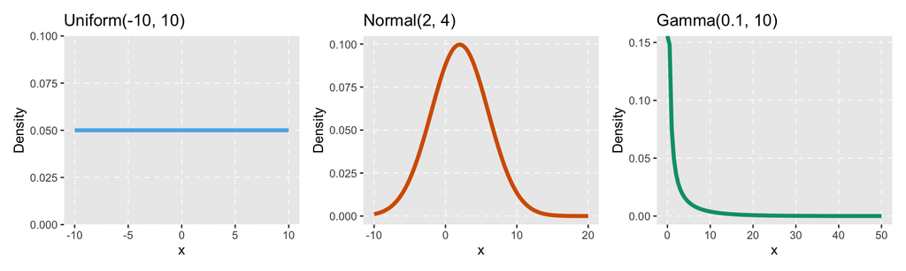

## Uniform Priors

$$\text{Posterior} \propto \text{Likelihood} \times \text{Prior}$$

If your prior is uniform, it applies the same multiplier to each possible value of $\theta$ (your given parameter). So…

$$\text{Posterior} \propto \text{Likelihood}$$

## Uniform Priors

**Pros**:

- “Objective” 🙄
- let’s the “data speak for themselves”
- easy to explain
- sometimes gives results roughly equivalent to Frequentist estimates

**Cons**:

- you often know *something* (non-regularizing)
- non-invariance under re-parameterization
- improper over $\mathbb{R_n}$

## Uniform Priors (Freq)

```r
library(brms)
# freq
lm(y ~ x, data = df) |> summary()
```

```
Call:
lm(formula = y ~ x, data = df)

Residuals:
    Min      1Q  Median      3Q     Max
-2.7258 -0.8607  0.0228  0.9791  2.7093

Coefficients:
            Estimate Std. Error t value Pr(>|t|)
(Intercept)   0.4391     0.1138   3.859 0.000204 ***
x            -0.5795     0.1168  -4.960 2.96e-06 ***
---
Signif. codes:  0 '***' 0.001 '**' 0.01 '*' 0.05 '.' 0.1 ' ' 1

Residual standard error: 1.134 on 98 degrees of freedom
Multiple R-squared:  0.2007,    Adjusted R-squared:  0.1925
F-statistic:  24.6 on 1 and 98 DF,  p-value: 2.963e-06
```

## Uniform Priors (Bayes)

```r
# bayes
priors <- c(
  prior("", class = "b"),
  prior("", class = "Intercept"),
  prior("uniform(0, 1e6)", class = "sigma")
)
brm(y ~ x, data = df, prior = priors, verbose = 2) |> summary()
```

```
 Family: gaussian
  Links: mu = identity; sigma = identity
Formula: y ~ x
   Data: df (Number of observations: 100)
  Draws: 4 chains, each with iter = 2000; warmup = 1000; thin = 1;
         total post-warmup draws = 4000

Regression Coefficients:
          Estimate Est.Error l-95% CI u-95% CI Rhat Bulk_ESS Tail_ESS
Intercept     0.44      0.11     0.22     0.65 1.00     3794     2941
x            -0.58      0.12    -0.81    -0.35 1.00     4179     3027

Further Distributional Parameters:
      Estimate Est.Error l-95% CI u-95% CI Rhat Bulk_ESS Tail_ESS
sigma     1.15      0.08     1.00     1.32 1.00     3934     2781

Draws were sampled using sampling(NUTS). For each parameter, Bulk_ESS
and Tail_ESS are effective sample size measures, and Rhat is the potential
scale reduction factor on split chains (at convergence, Rhat = 1).
```

## Uniform Priors (Non-Invariance)

Consider a **logistic regression**:

$$\underbrace{\mathbb{E}\left( y | \mathbf{X} \right)}_\text{pred prob} = \frac{1}{1 + e^{-\mathbf{X}\beta}}$$

- **Parameterization 1**: estimate log odds coefficients $\beta$s
- **Parameterization 2**: estimate odds coefficients $e^{\beta}$

## Uniform Priors (Non-Invariance)

### Parameterization 1

Let’s feign ignorance…we know *nothing* about what $\beta$s should be, so we place a uniform prior on the coefficients.

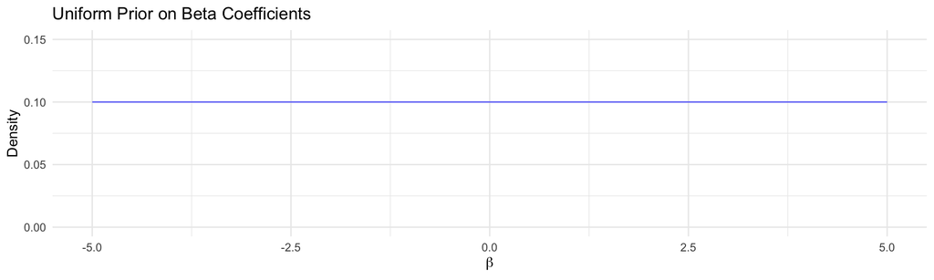

## Uniform Priors (Non-Invariance)

### Parameterization 2

By the same logic…we know *nothing* about what $e^{\beta}$s should be, so we place a uniform prior on the coefficients.

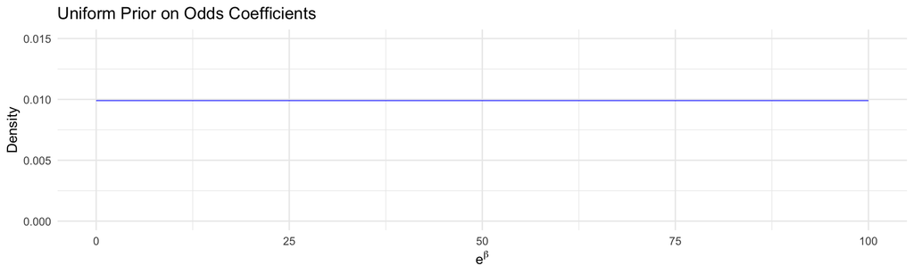

## Uniform Priors (Non-Invariance)

First, let’s look at what **Parameterization 1** (uniform prior on $\beta$) implies about $e^\beta$:

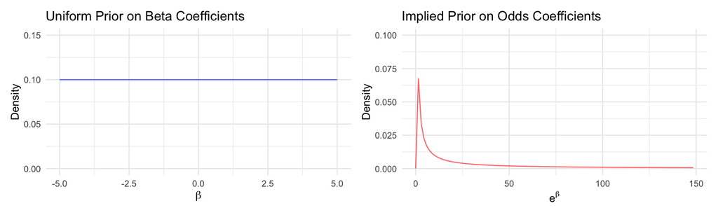

## Uniform Priors (Non-Invariance)

First, let’s look at what **Parameterization 1** (uniform prior on $\beta$) implies about $e^\beta$:

$$p_{\beta}(\beta) = \frac{1}{upper - lower} = \frac{1}{b-a}$$

let $\theta = e^\beta$ so $\beta = ln(\theta)$:

$$\underbrace{p_\theta(\theta) = p_\beta(\beta) \cdot \lvert\frac{d \beta}{d \theta}\rvert}_\text{change of variable} \\
p_\theta(\theta) = \frac{1}{b-a} \cdot \lvert\frac{1}{\theta}\rvert = \frac{1}{(b-a)\theta}$$

❗ this does not give all $\theta$s the same likelihood!!!

## Uniform Priors (Non-Invariance)

Now, let’s look at what **Parameterization 2** (uniform prior on $e^\beta$) implies about $\beta$:

$$p_{\theta}(\theta) = \frac{1}{upper - lower} = \frac{1}{b-a}$$

$\beta = ln(\theta)$ so $\theta = e^\beta$:

$$\underbrace{p_\beta(\beta) = p_\theta(\theta) \cdot \lvert\frac{d \theta}{d \beta}\rvert}_\text{change of variable} \\
p_\beta(\beta) = \frac{1}{b-a} \cdot \lvert e^\beta\rvert = \frac{e^\beta}{(b-a)}$$

## Uniform Priors (Non-Invariance)

Now, let’s look at what **Parameterization 2** (uniform prior on $e^\beta$) implies about $\beta$:

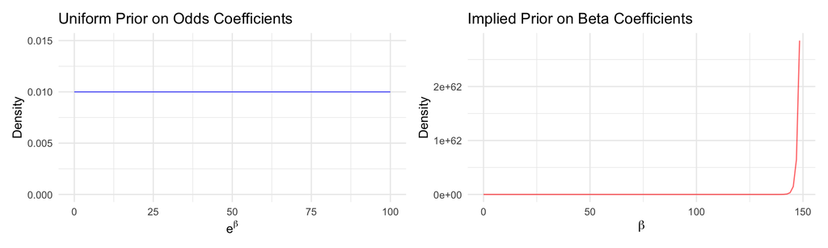

## Uniform Priors (Non-Invariance)

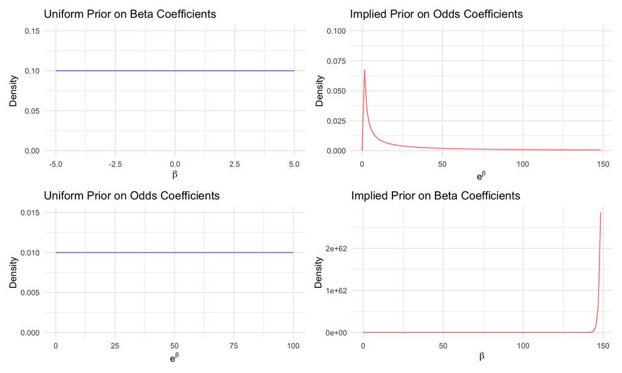

## Jeffrey’s Prior

$$p(\theta) \propto \sqrt{I(\theta)}$$

- **Jeffrey’s Prior**: method of constructing non-informative priors that *are* **invariant** under re-parameterization

(see Bayesian Data Analysis 2.8 for more math)

## Jeffrey’s Prior

What does “invariant under re-parameterization” mean?

If there are two ways to parameterize our problem (e.g. think of estimating the proportion of heads, $\theta$ vs $\nu = \frac{\theta}{1-\theta}$ the odds of heads), we want the **priors** on $\theta$ or $\nu$ to imply the same information.

## Jeffrey’s Prior

What does “non-informative” mean?

“*let the data speak for themselves”*. Typically there are a few sources of info for priors.

1. **structural information**: literal limitations of the data. If a parameter can’t be negative, don’t include negative values. If a scale goes from 0-100 nothing could possibly have an effect bigger than 101 points…etc.
2. **past data**: similar studies that were run in the past, typical values from past A/B tests…etc.
3. **expert opinion**: a more hand-wavy way to look at past data (John says X and John’s worked in marketing for 20 years).

All but #1 are seen as potentially “biased” sources of info (potentially biased does not mean WRONG).

## Jeffrey’s Prior

Jeffrey’s Prior aims to give a relatively **non-informative** prior that *is* **invariant under re-parameterization**.

## Fisher Information

**Slightly Mathy Idea**: Fisher Information measures how *sensitive* the log-likelihoodfunction $\ell(\theta | X)$ is to changes in $\theta$ (more sensitive $\to$ more information)

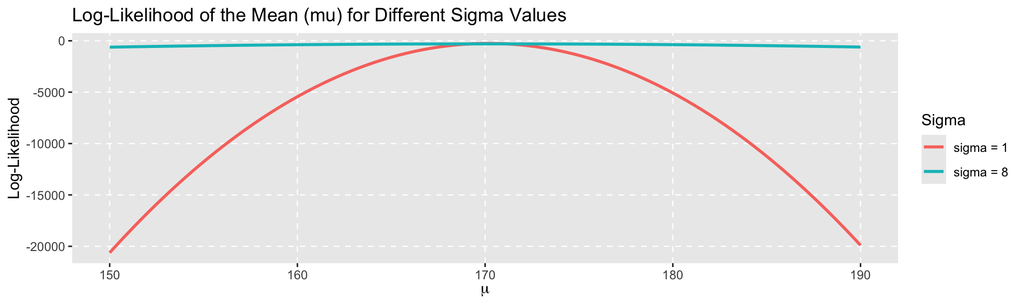

## Fisher Information

**Math Idea**:

$$I_X(\theta) = -\mathbb{E}\left[\frac{\partial^2 \ell(\theta | X)}{\partial\theta^2} \right]$$

where $\ell(\theta | X)$ is the log-likelihood of $\theta$ given $X$. If $\ell$ is sensitive to changes in $\theta$, the second derivative should be *large* and we expect to see *high* information

Note: usually $\ell$ is concave down around maximum likelihood estimate, meaning that the second-derivative will be negative, hence the negative sign in front of the expectation

## Fisher Information

Let’s look at our coin flipping example where $\theta$ is the proportion of heads.

- $J(\theta) \propto \sqrt{(I(\theta))}$ Jeffrey’s prior definition
- $I_X(\theta) = - \mathbb{E}\left(\frac{\partial^2 \ell(\theta|X)}{\partial \theta^2} \right)$ Fisher Information
- $\mathcal{L}(\theta|X) = \theta^x(1-\theta)^{1-x}$ so $\ell(\theta|X) = \log \mathcal{L} = X \log \theta + (1-X) \log(1-\theta)$

So far these are just definitions.

## Fisher Information

Let’s look at our coin flipping example where $\theta$ is the proportion of heads.

- $\mathcal{L}(\theta|X) = \theta^x(1-\theta)^{1-x}$ so $\ell(\theta|X) = \log \mathcal{L} = X \log \theta + (1-X) \log(1-\theta)$
- $\frac{\partial \ell}{\partial \theta} = \frac{X}{\theta} - \frac{1-X}{1-\theta}$ take the first derivative of the log likelihood
- $\frac{\partial^2 \ell}{\partial \theta^2} = -\frac{X}{\theta^2}- \frac{1-X}{(1-\theta)^2}$ take the second derivative of the log likelihood
- $\mathbb{E}(\frac{x}{\theta^2} + \frac{1-x}{(1-\theta)^2}) = \frac{\theta}{\theta^2} + \frac{1-\theta}{(1-\theta)^2} = \frac{1}{\theta(1-\theta)}$ Fisher information

just a little calculus…

## Fisher Information

- $\mathbb{E}(\frac{x}{\theta^2} + \frac{1-x}{(1-\theta)^2}) = \frac{\theta}{\theta^2} + \frac{1-\theta}{(1-\theta)^2} = \frac{1}{\theta(1-\theta)}$ Fisher information
- $J(\theta) \propto \sqrt{(I(\theta))}$ Jeffrey’s prior definition
- $J(\theta) = \frac{1}{\theta^{1/2}(1-\theta)^{1/2}}$

## Jeffrey’s Prior

Jeffrey’s Prior aims to give a relatively **non-informative** prior that *is* **invariant under re-parameterization**.

- **invariant under re-parameterization**: if we instead worked out $J(\nu)$ for the *odds* of heads, and then transformed it back into $\theta$ terms, we’d get this same prior.

this is useful because someone can then take your prior/posterior and transform it to use their preferred units and get the same result as if they did it their way in the first place.

## Jeffrey’s Prior

Jeffrey’s Prior aims to give a relatively **non-informative** prior that *is* **invariant under re-parameterization**.

- **non-informative**: the prior uses only the **structure** of the problem, not any past data/expertise. It basically reflects the shape of the likelihood.

If we observe $\hat{\theta} = 0.5$ in a sample, there are MANY $\theta$ that could have generated that. If we get ALL heads, it’s quite unlikely that most $\theta$’s generated that. It’s the amount of information the data *could carry* about each possible $\theta$.

## Jeffrey’s Prior

Takeaways:

- non-informative priors don’t HAVE to mean flat priors
- non-informative priors try to take as little info in from sources outside the structure of the problem
- when priors are invariant under re-parameterization, we can be confident that the prior we generate is the same as one we’d generate under a different parameterization (e.g. $\theta$ vs $\nu$)
- **Think carefully about what your priors imply**
- **Non-informative/Uniformative priors can take different forms**

## Regularizing Priors

**Regularization** (in general): discourages overfitting, makes models simpler

**Regularizing** Priors: keeps parameter values in a “reasonable range”

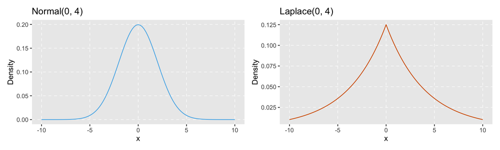

## Regularizing Priors

Ridge = Normal Prior, Lasso = Laplacian Prior.

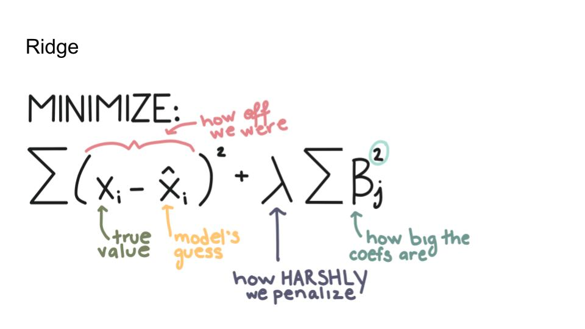

## Other Types of Priors

- **Uniformative**: all possible values for $\theta$ have the same relative prior likelihood
- **Weakly Informative**: regularize our estimates, extreme values are less likely, but not much other info
- **Strongly Informative**: prior is narrow around known likely values

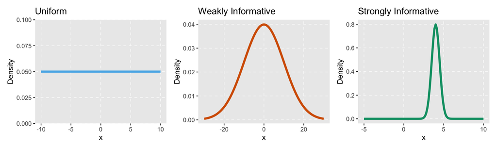

## Other Types of Priors

- **Uniformative**: all possible values for $\theta$ have the same relative prior likelihood
- **Weakly Informative**: regularize our estimates, extreme values are less likely, but not much other info
- **Strongly Informative**: prior is narrow around known likely values

**When would you use each type of prior?**

## Choosing Prior Distributions

- think about the range of possible values of $\theta$
- think about amount of prior **uncertainty**
- think about **regularization**

In reality, we often report 2-3 different versions of the models with various priors to see how these priors change the inferences we make.

## Setting Priors in `brms`

```r
set.seed(540)
n <- 100
x <- rnorm(n)
y <- 0.25 - x*0.5 + rnorm(n)
df <- data.frame(x,y)

# bayes
priors <- c(
  prior("normal(0,5)", class = "b"),
  prior("normal(0,4)", class = "Intercept"),
  prior("gamma(0.1, 10)", class = "sigma")
)
brm(y ~ x, data = df, prior = priors, verbose = 2) |> summary()
```

[output not shown]

```
CHECKING DATA AND PREPROCESSING FOR MODEL 'anon_model' NOW.

COMPILING MODEL 'anon_model' NOW.

STARTING SAMPLER FOR MODEL 'anon_model' NOW.
```

```
 Family: gaussian
  Links: mu = identity; sigma = identity
Formula: y ~ x
   Data: df (Number of observations: 100)
  Draws: 4 chains, each with iter = 2000; warmup = 1000; thin = 1;
         total post-warmup draws = 4000

Regression Coefficients:
          Estimate Est.Error l-95% CI u-95% CI Rhat Bulk_ESS Tail_ESS
Intercept     0.25      0.09     0.07     0.44 1.00     3900     3130
x            -0.49      0.10    -0.70    -0.29 1.00     3793     2966

Further Distributional Parameters:
      Estimate Est.Error l-95% CI u-95% CI Rhat Bulk_ESS Tail_ESS
sigma     0.98      0.07     0.86     1.12 1.00     3827     2876

Draws were sampled using sampling(NUTS). For each parameter, Bulk_ESS
and Tail_ESS are effective sample size measures, and Rhat is the potential
scale reduction factor on split chains (at convergence, Rhat = 1).
```